# Beyond Zipf’s Law: a reproducible generative benchmark

v0.5.1 — stable latent calibration, Markov control, MLE robustness, bootstrap AUC, joint matching, and NMI sensitivity

Author

Working reproducibility notebook

Published

August 8, 2026

## Purpose of v0.5.1

Version 0.5.1 freezes the benchmark architecture introduced in v0.5 and makes one prespecified numerical correction: the **latent-mixture parameter is selected on a 50-seed calibration panel** rather than on 10 seeds. The held-out evaluation panel remains seeds 2001 onward and is never used for calibration.

The notebook addresses five robustness questions raised during review:

1. **Sequential control:** a stationary non-SSR Markov process has the same finite-Zipf marginal as the exchangeable reference but non-zero temporal dependence.
2. **Estimator robustness:** the deliberately simple OLS log–log exponent is compared with a conditional discrete-likelihood estimate on the identical rank window.
3. **Uncertainty in discrimination:** pairwise AUC effects are accompanied by bootstrap intervals for the signed rank effect $R=2\operatorname{AUC}-1$.
4. **Joint matching:** a second benchmark matches $(\widehat\alpha,V_n)$ before evaluating diagnostics not used in calibration.
5. **NMI sensitivity:** excess lag-1 normalized mutual information is recomputed after retaining $K=25,50,100$ frequent types plus one `OTHER` category.

The central inferential hierarchy is therefore

$$\text{marginal scaling}
\longrightarrow
\text{order dependence}
\longrightarrow
\text{directional/history-dependent structure}.$$

```r
required <- c("ggplot2", "patchwork", "knitr")
missing <- required[!vapply(required, requireNamespace, logical(1), quietly = TRUE)]
if (length(missing)) {
  stop("Install required packages first: ", paste(missing, collapse = ", "))
}

source("R/generators.R")
source("R/diagnostics.R")
source("R/calibration.R")
source("R/figures.R")
source("R/run_all.R")

dir.create("figures", showWarnings = FALSE, recursive = TRUE)
dir.create("results", showWarnings = FALSE, recursive = TRUE)
dir.create("tables", showWarnings = FALSE, recursive = TRUE)
set.seed(20260808)

parse_integer_vector <- function(x) {
  as.integer(trimws(strsplit(as.character(x), ",", fixed = TRUE)[[1L]]))
}
nmi_top_k_values <- parse_integer_vector(params$nmi_top_k_values)

fmt_mean_sd <- function(mean, sd, digits = 3L) {
  sprintf(paste0("%.", digits, "f (%.", digits, "f)"), mean, sd)
}

save_table <- function(df, stem, caption = NULL, digits = 3L) {
  csv_path <- file.path("tables", paste0(stem, ".csv"))
  tex_path <- file.path("tables", paste0(stem, ".tex"))
  utils::write.csv(df, csv_path, row.names = FALSE)
  latex <- knitr::kable(
    df, format = "latex", booktabs = TRUE, digits = digits,
    caption = caption, escape = TRUE
  )
  writeLines(as.character(latex), tex_path)
  knitr::kable(df, format = "html", digits = digits, caption = caption)
}
```

## One-click use in RStudio

A fresh copy of this repository can be rendered directly in RStudio. With the default settings above, the first **Render** runs the full paper analysis because the required result files do not yet exist. Later renders detect those files and rebuild only the notebook, tables and figures.

To deliberately rerun every calibration and held-out replication, set

```yaml
force_rerun: true
```

and render once. Set it back to `false` afterwards.

```r
should_run <- isTRUE(params$run_simulations) &&
  (isTRUE(params$force_rerun) || !paper_outputs_exist("results"))

if (should_run) {
  if (isTRUE(params$quick)) {
    run_all(
      n_rep = 10L,
      n_cal_seeds = 3L,
      n_latent_cal_seeds = 8L,
      n_surrogates = 3L,
      heaps_window = as.integer(params$heaps_window),
      n_boot = 250L,
      nmi_top_k_values = nmi_top_k_values
    )
  } else {
    run_all(
      n_rep = as.integer(params$n_rep),
      n_cal_seeds = as.integer(params$n_cal_seeds),
      n_latent_cal_seeds = as.integer(params$n_latent_cal_seeds),
      n_surrogates = as.integer(params$n_surrogates),
      heaps_window = as.integer(params$heaps_window),
      n_boot = as.integer(params$n_boot),
      nmi_top_k_values = nmi_top_k_values
    )
  }
} else if (paper_outputs_exist("results")) {
  cat("Existing paper outputs found: simulations were not rerun.\n")
}
```

```
Existing paper outputs found: simulations were not rerun.
```

```r
needed_results <- .paper_outputs("results")
missing_results <- needed_results[!file.exists(needed_results)]
if (length(missing_results)) {
  stop(
    "Missing simulation outputs: ", paste(missing_results, collapse = ", "),
    ". Set run_simulations: true (or force_rerun: true) and Render once."
  )
}
```

# 1. Calibration design

## 1.1 Stable latent-mixture calibration

The latent construction showed greater Monte Carlo variability than the other benchmark constructions. Version 0.5.1 therefore uses a two-stage procedure that remains completely separate from held-out evaluation:

- the broad latent grid is screened on a small prespecified subset of calibration seeds;
- the best regions and local refinements are evaluated on **50 calibration seeds**;
- the final latent parameter is selected from this 50-seed calibration panel;
- evaluation still uses seeds 2001–2100.

This change increases calibration precision without using any held-out information for tuning.

```r
cal_exp <- readRDS("results/calibration_exponent.rds")
cal_joint <- readRDS("results/calibration_joint.rds")
cal_exp_summary <- utils::read.csv("results/calibration_exponent_summary.csv", stringsAsFactors = FALSE)
cal_joint_summary <- utils::read.csv("results/calibration_joint_summary.csv", stringsAsFactors = FALSE)

save_table(
  cal_exp_summary,
  "table_calibration_exponent_v051",
  caption = "Exponent-only calibration. The latent-mixture final parameter is selected on the enlarged calibration panel."
)
```

Exponent-only calibration. The latent-mixture final parameter is selected on the enlarged calibration panel.

| model | stage | n_calibration_seeds | mean_alpha | sd_alpha | abs_alpha_bias | alpha_rmse | mean_vocabulary | sd_vocabulary | loss | relative_vocabulary_error | within_alpha_tolerance | within_vocabulary_tolerance |
| --- | --- | --- | --- | --- | --- | --- | --- | --- | --- | --- | --- | --- |
| random | coarse | 10 | 1.001 | 0.007 | 0.001 | 0.007 | 12205.7 | 132.070 | 0.003 | 1.441 | TRUE | FALSE |
| simon | coarse | 10 | 0.998 | 0.064 | 0.002 | 0.061 | 4488.6 | 51.123 | 0.009 | 0.102 | TRUE | FALSE |
| ssr | refined | 10 | 0.991 | 0.003 | 0.009 | 0.009 | 5016.8 | 11.322 | 0.123 | 0.003 | TRUE | TRUE |
| latent | 50-seed-final | 50 | 1.001 | 0.033 | 0.001 | 0.033 | 4739.3 | 64.066 | 0.002 | 0.052 | TRUE | FALSE |

```r
save_table(
  cal_joint_summary,
  "table_calibration_joint_v051",
  caption = "Joint calibration targeting the OLS exponent and final vocabulary size."
)
```

Joint calibration targeting the OLS exponent and final vocabulary size.

| model | stage | n_calibration_seeds | mean_alpha | sd_alpha | abs_alpha_bias | alpha_rmse | mean_vocabulary | sd_vocabulary | loss | relative_vocabulary_error | within_alpha_tolerance | within_vocabulary_tolerance |
| --- | --- | --- | --- | --- | --- | --- | --- | --- | --- | --- | --- | --- |
| maxent | refined | 10 | 0.991 | 0.005 | 0.009 | 0.010 | 4984.80 | 12.054 | 0.143 | 0.003 | TRUE | TRUE |
| markov | refined | 10 | 0.984 | 0.005 | 0.016 | 0.017 | 4992.90 | 15.037 | 0.432 | 0.001 | FALSE | TRUE |
| ssr | refined | 10 | 0.991 | 0.003 | 0.009 | 0.009 | 4990.60 | 10.906 | 0.125 | 0.002 | TRUE | TRUE |
| latent | 50-seed-final | 50 | 0.996 | 0.034 | 0.004 | 0.034 | 4986.46 | 65.539 | 0.037 | 0.003 | TRUE | TRUE |

# 2. Generative constructions and observation map

The strict benchmark contains four constructions with deliberately different dependence structures.

**Finite Zipf reference.** Independent tokens are sampled from

$$p(r;1,V)=\frac{r^{-1}}{\sum_{j=1}^V j^{-1}}.$$

It is a transparent constraint-based reference rather than a dynamical mechanism.

**Zipf Markov control.** The stationary marginal is the same finite-Zipf distribution, while transitions follow

$$P_{ij}=\rho\mathbf 1\{i=j\}+(1-\rho)p_j,
\qquad \rho=0.35.$$

It therefore provides a non-SSR process with genuine serial dependence.

**Latent mixture.** Sequences are conditionally non-Zipfian but heterogeneous in scale; pooling can create an approximately Zipfian marginal (Schwab et al. 2014; Aitchison et al. 2016).

**Sample-space reduction.** The current state restricts the accessible future state space until restart (Corominas-Murtra et al. 2015; Thurner et al. 2015).

Random segmentation and Simon reinforcement are retained separately as observation-window / compatibility examples (Simon 1955; Li 1992; Conrad and Mitzenmacher 2004; Ferrer-i-Cancho and Elvevåg 2010).

The prespecified primary rank summary remains

$$10\le r\le500,\qquad N_{(r)}\ge5,$$

with

$$\log \widehat p_{(r)}=a-\widehat\alpha_{\mathrm{OLS}}\log r+\varepsilon_r.$$

This OLS slope is intentionally a low-dimensional descriptive statistic, not a stand-alone power-law goodness-of-fit test (Clauset et al. 2009).

The likelihood robustness estimator uses the same retained ranks $\mathcal R$:

$$q_r(\alpha)=\frac{r^{-\alpha}}{\sum_{j\in\mathcal R}j^{-\alpha}},$$

$$\ell(\alpha)
=-\alpha\sum_{r\in\mathcal R}N_{(r)}\log r
-N_{\mathcal R}\log\left(\sum_{j\in\mathcal R}j^{-\alpha}\right).$$

# 3. Held-out benchmark

```r
rep_strict <- readRDS("results/benchmark_strict_replications.rds")
rep_mimic <- readRDS("results/benchmark_mimicking_replications.rds")
rep_joint <- readRDS("results/benchmark_joint_strict_replications.rds")
auc_boot <- utils::read.csv("results/diagnostic_pairwise_auc_bootstrap_strict.csv", stringsAsFactors = FALSE)
auc_boot_joint <- utils::read.csv("results/diagnostic_pairwise_auc_bootstrap_joint.csv", stringsAsFactors = FALSE)
nmi_topk <- utils::read.csv("results/nmi_topk_sensitivity_strict.csv", stringsAsFactors = FALSE)

strict_parameters <- strict_benchmark_parameters(
  exponent_parameters = cal_exp$selected,
  n_tokens = 100000L,
  maxent_vocabulary_size = 5000L,
  markov_vocabulary_size = 5000L,
  markov_persistence = 0.35
)
sims_strict <- simulate_strict_benchmark_once(
  seed = 2001L, n_tokens = 100000L, parameters = strict_parameters
)
```

## 3.1 Main numerical table

```r
strict_summary <- diagnostic_summary_table(rep_strict)
get_diag <- function(g, v, field = "mean") {
  x <- strict_summary[strict_summary$generator == g & strict_summary$diagnostic == v, field]
  if (!length(x)) NA_real_ else x[1L]
}
get_diag_sd <- function(g, v) get_diag(g, v, "sd")

generators <- unique(rep_strict$generator)
strict_wide <- data.frame(
  Construction = generators,
  `OLS alpha` = vapply(generators, function(g) fmt_mean_sd(get_diag(g, "alpha"), get_diag_sd(g, "alpha")), character(1)),
  `MLE alpha` = vapply(generators, function(g) fmt_mean_sd(get_diag(g, "alpha_mle"), get_diag_sd(g, "alpha_mle")), character(1)),
  `Final V` = vapply(generators, function(g) fmt_mean_sd(get_diag(g, "vocabulary"), get_diag_sd(g, "vocabulary"), digits = 1L), character(1)),
  `Excess NMI` = vapply(generators, function(g) fmt_mean_sd(get_diag(g, "transition_nmi_excess"), get_diag_sd(g, "transition_nmi_excess")), character(1)),
  `Direction D` = vapply(generators, function(g) fmt_mean_sd(get_diag(g, "transition_toward_more_frequent"), get_diag_sd(g, "transition_toward_more_frequent")), character(1)),
  check.names = FALSE,
  stringsAsFactors = FALSE
)
save_table(
  strict_wide,
  "table_heldout_strict_v051",
  caption = "Held-out diagnostics (mean and standard deviation across independent replications)."
)
```

Held-out diagnostics (mean and standard deviation across independent replications).

|  | Construction | OLS alpha | MLE alpha | Final V | Excess NMI | Direction D |
| --- | --- | --- | --- | --- | --- | --- |
| finite Zipf reference | finite Zipf reference | 0.992 (0.005) | 0.995 (0.004) | 4857.8 (12.1) | 0.000 (0.000) | 0.500 (0.001) |
| Zipf Markov control | Zipf Markov control | 0.984 (0.007) | 0.989 (0.005) | 4601.0 (16.2) | 0.188 (0.002) | 0.500 (0.001) |
| latent mixture | latent mixture | 0.994 (0.031) | 1.004 (0.029) | 4755.4 (59.9) | -0.000 (0.001) | 0.500 (0.001) |
| sample-space reduction | sample-space reduction | 0.993 (0.005) | 0.995 (0.004) | 5013.3 (12.6) | 0.350 (0.001) | 0.946 (0.001) |

## 3.2 Marginal scaling and OLS/MLE robustness

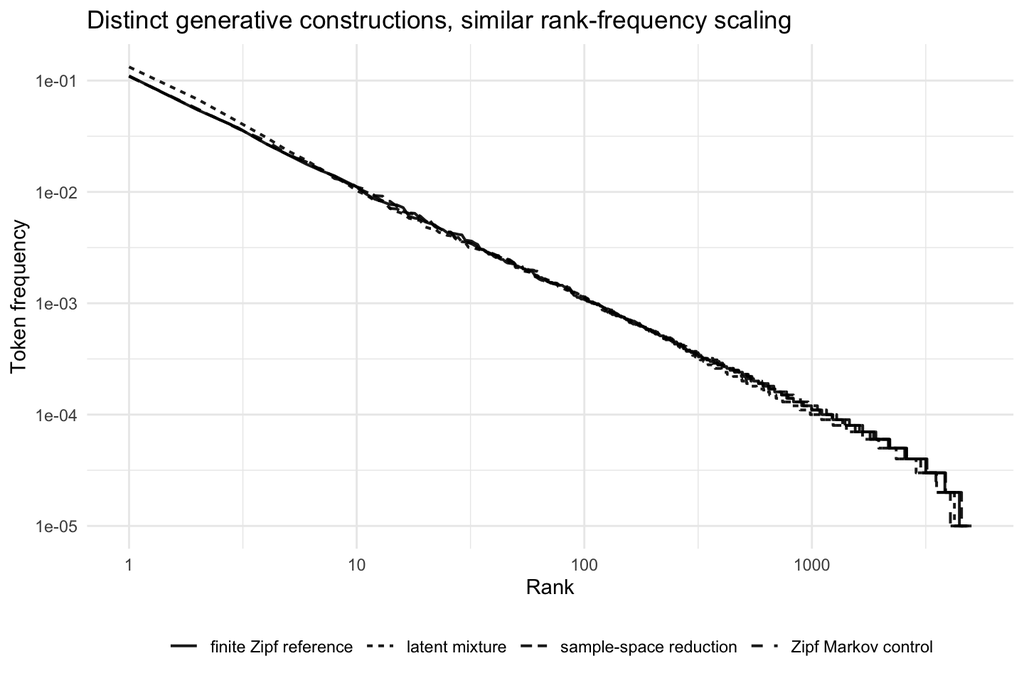

Figure 1: Distinct constructions can display similar marginal rank–frequency scaling in a held-out realization.

```r
p_rank <- plot_rank_frequency(sims_strict)
p_rank
ggplot2::ggsave("figures/fig_rank_frequency_v051.pdf", p_rank, width = 7.5, height = 5)
```

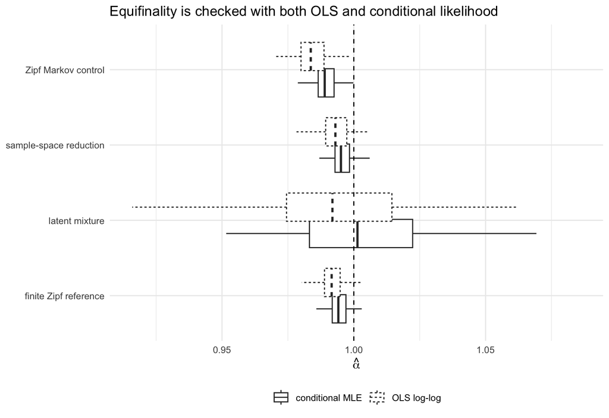

Figure 2: Held-out rank-exponent estimates under the prespecified OLS summary and conditional discrete likelihood.

```r
p_estimators <- plot_alpha_estimator_comparison(rep_strict)
p_estimators
ggplot2::ggsave("figures/fig_alpha_estimator_robustness_v051.pdf", p_estimators, width = 8, height = 5.5)
```

# 4. Sequential control: generic order dependence versus SSR directionality

Excess lag-1 normalized mutual information is calculated after retaining the $K$ most frequent types plus `OTHER` and subtracting the expectation under within-sequence shuffling:

$$I_{\mathrm{excess}}(K)
=I_{\mathrm{NMI}}^{(K)}(X_t;X_{t+1})
-E_{\mathrm{shuffle}}\left[I_{\mathrm{NMI}}^{(K)}(X_t;X_{t+1})\right].$$

This statistic tests for order dependence. It is deliberately **not** interpreted as SSR-specific. Directionality is measured separately by

$$D=P(R_{t+1}<R_t\mid R_{t+1}\ne R_t).$$

For exchangeable pairs, and for the stationary refresh component of the Markov control conditional on a change, symmetry gives $D\simeq1/2$. Canonical SSR instead predicts a strong directional asymmetry.

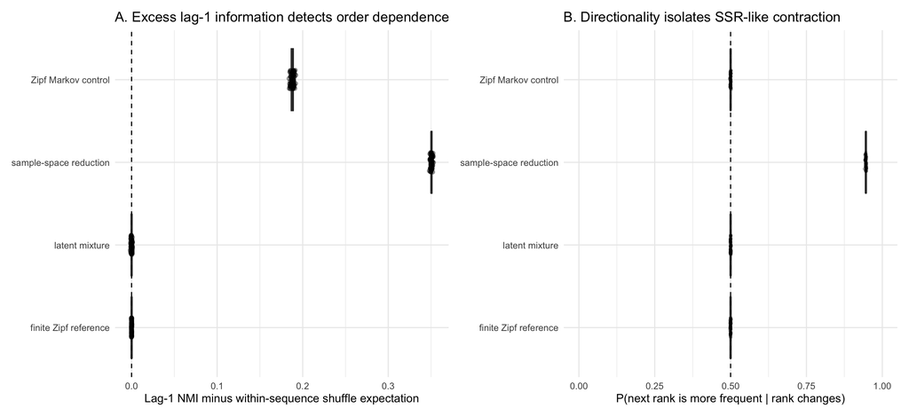

Figure 3: The Markov control separates generic sequential dependence from SSR-like directionality: excess information detects order dependence, while transition direction isolates the asymmetric sample-space-reduction signature.

```r
p_sequence <- plot_sequence_diagnostic_figure(rep_strict)
p_sequence
ggplot2::ggsave("figures/fig_sequence_identification_v051.pdf", p_sequence, width = 12, height = 5.5)
```

# 5. Bootstrap uncertainty in pairwise discrimination

For a scalar diagnostic $T$, pairwise discrimination is summarized by the signed rank effect

$$R_T=2\operatorname{AUC}_T-1\in[-1,1].$$

The absolute value $|R_T|$ is a bounded effect size: 0 denotes no ordinal discrimination and 1 perfect separation. We bootstrap the two held-out samples independently and report 95% intervals for the **signed** effect, so near-zero absolute effects are not mistaken for precise evidence of separation.

```r
auc_key <- auc_boot[auc_boot$diagnostic %in% c(
  "alpha", "alpha_mle", "transition_nmi_excess", "transition_toward_more_frequent"
), c(
  "pair", "diagnostic", "rank_effect", "rank_effect_lower", "rank_effect_upper",
  "separation", "ci_contains_zero", "n_x", "n_y"
)]
auc_key$rank_effect <- round(auc_key$rank_effect, 3)
auc_key$rank_effect_lower <- round(auc_key$rank_effect_lower, 3)
auc_key$rank_effect_upper <- round(auc_key$rank_effect_upper, 3)
auc_key$separation <- round(auc_key$separation, 3)
save_table(
  auc_key,
  "table_auc_bootstrap_key_v051",
  caption = "Pairwise signed AUC rank effects and 95% bootstrap intervals for the principal marginal and sequential diagnostics."
)
```

Pairwise signed AUC rank effects and 95% bootstrap intervals for the principal marginal and sequential diagnostics.

|  | pair | diagnostic | rank_effect | rank_effect_lower | rank_effect_upper | separation | ci_contains_zero | n_x | n_y |
| --- | --- | --- | --- | --- | --- | --- | --- | --- | --- |
| 1 | finite Zipf reference vs Zipf Markov control | alpha | 0.646 | 0.530 | 0.762 | 0.646 | FALSE | 100 | 100 |
| 2 | finite Zipf reference vs Zipf Markov control | alpha_mle | 0.588 | 0.465 | 0.706 | 0.588 | FALSE | 100 | 100 |
| 6 | finite Zipf reference vs Zipf Markov control | transition_toward_more_frequent | -0.099 | -0.256 | 0.074 | 0.099 | TRUE | 100 | 100 |
| 7 | finite Zipf reference vs Zipf Markov control | transition_nmi_excess | -1.000 | -1.000 | -1.000 | 1.000 | FALSE | 100 | 100 |
| 8 | finite Zipf reference vs latent mixture | alpha | -0.012 | -0.196 | 0.174 | 0.012 | TRUE | 100 | 100 |
| 9 | finite Zipf reference vs latent mixture | alpha_mle | -0.174 | -0.351 | 0.013 | 0.174 | TRUE | 100 | 100 |
| 13 | finite Zipf reference vs latent mixture | transition_toward_more_frequent | -0.126 | -0.283 | 0.034 | 0.126 | TRUE | 100 | 100 |
| 14 | finite Zipf reference vs latent mixture | transition_nmi_excess | 0.031 | -0.141 | 0.196 | 0.031 | TRUE | 100 | 100 |
| 15 | finite Zipf reference vs sample-space reduction | alpha | -0.128 | -0.288 | 0.036 | 0.128 | TRUE | 100 | 100 |
| 16 | finite Zipf reference vs sample-space reduction | alpha_mle | -0.130 | -0.293 | 0.034 | 0.130 | TRUE | 100 | 100 |
| 20 | finite Zipf reference vs sample-space reduction | transition_toward_more_frequent | -1.000 | -1.000 | -1.000 | 1.000 | FALSE | 100 | 100 |
| 21 | finite Zipf reference vs sample-space reduction | transition_nmi_excess | -1.000 | -1.000 | -1.000 | 1.000 | FALSE | 100 | 100 |
| 22 | Zipf Markov control vs latent mixture | alpha | -0.235 | -0.404 | -0.060 | 0.235 | FALSE | 100 | 100 |
| 23 | Zipf Markov control vs latent mixture | alpha_mle | -0.318 | -0.483 | -0.146 | 0.318 | FALSE | 100 | 100 |
| 27 | Zipf Markov control vs latent mixture | transition_toward_more_frequent | -0.011 | -0.159 | 0.151 | 0.011 | TRUE | 100 | 100 |
| 28 | Zipf Markov control vs latent mixture | transition_nmi_excess | 1.000 | 1.000 | 1.000 | 1.000 | FALSE | 100 | 100 |
| 29 | Zipf Markov control vs sample-space reduction | alpha | -0.703 | -0.801 | -0.599 | 0.703 | FALSE | 100 | 100 |
| 30 | Zipf Markov control vs sample-space reduction | alpha_mle | -0.685 | -0.785 | -0.573 | 0.685 | FALSE | 100 | 100 |
| 34 | Zipf Markov control vs sample-space reduction | transition_toward_more_frequent | -1.000 | -1.000 | -1.000 | 1.000 | FALSE | 100 | 100 |
| 35 | Zipf Markov control vs sample-space reduction | transition_nmi_excess | -1.000 | -1.000 | -1.000 | 1.000 | FALSE | 100 | 100 |
| 36 | latent mixture vs sample-space reduction | alpha | -0.016 | -0.201 | 0.168 | 0.016 | TRUE | 100 | 100 |
| 37 | latent mixture vs sample-space reduction | alpha_mle | 0.149 | -0.041 | 0.324 | 0.149 | TRUE | 100 | 100 |
| 41 | latent mixture vs sample-space reduction | transition_toward_more_frequent | -1.000 | -1.000 | -1.000 | 1.000 | FALSE | 100 | 100 |
| 42 | latent mixture vs sample-space reduction | transition_nmi_excess | -1.000 | -1.000 | -1.000 | 1.000 | FALSE | 100 | 100 |

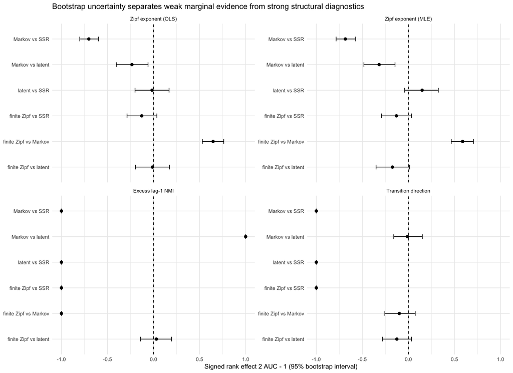

Figure 4: Bootstrap intervals distinguish weak exponent-based discrimination from strong structural separation.

```r
p_boot_key <- plot_bootstrap_selected_diagnostics(auc_boot)
p_boot_key
ggplot2::ggsave("figures/fig_bootstrap_key_diagnostics_v051.pdf", p_boot_key, width = 11, height = 8)
```

# 6. Sensitivity of excess NMI to alphabet collapse

```r
nmi_key <- aggregate(
  transition_nmi_excess ~ generator + top_k,
  data = nmi_topk,
  FUN = mean
)
nmi_wide <- reshape(
  nmi_key,
  idvar = "generator",
  timevar = "top_k",
  direction = "wide"
)
names(nmi_wide) <- sub("transition_nmi_excess\\.", "K=", names(nmi_wide))
for (j in seq_along(nmi_wide)) {
  if (is.numeric(nmi_wide[[j]])) nmi_wide[[j]] <- round(nmi_wide[[j]], 4)
}
save_table(
  nmi_wide,
  "table_nmi_sensitivity_v051",
  caption = "Mean excess lag-1 NMI after retaining the K most frequent types plus OTHER."
)
```

Mean excess lag-1 NMI after retaining the K most frequent types plus OTHER.

| generator | K=25 | K=50 | K=100 |
| --- | --- | --- | --- |
| finite Zipf reference | 0.000 | 0.000 | 0.000 |
| latent mixture | 0.000 | 0.000 | 0.000 |
| sample-space reduction | 0.378 | 0.350 | 0.320 |
| Zipf Markov control | 0.176 | 0.188 | 0.198 |

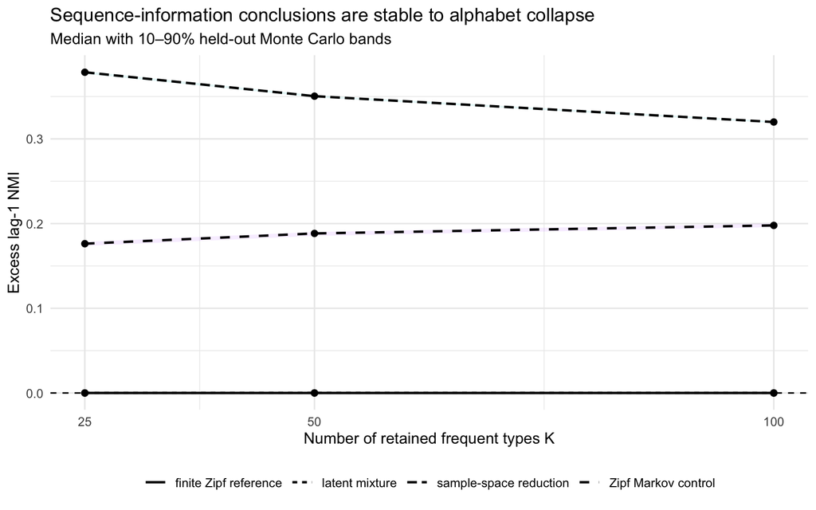

Figure 5: Sequence-information conclusions are stable when the collapsed alphabet retains 25, 50, or 100 frequent types.

```r
p_nmi_k <- plot_nmi_sensitivity(nmi_topk)
p_nmi_k
ggplot2::ggsave("figures/fig_nmi_topk_sensitivity_v051.pdf", p_nmi_k, width = 8, height = 5)
```

# 7. Joint matching on $(\widehat\alpha,V_n)$

The robustness benchmark explicitly targets

$$(\widehat\alpha_{\mathrm{OLS}},V_n)\approx(1,5000)$$

using only these two marginal summaries. The relevant question is whether diagnostics **not used in calibration** continue to distinguish the constructions.

```r
joint_summary <- diagnostic_summary_table(rep_joint)
get_joint <- function(g, v, field = "mean") {
  x <- joint_summary[joint_summary$generator == g & joint_summary$diagnostic == v, field]
  if (!length(x)) NA_real_ else x[1L]
}
joint_gens <- unique(rep_joint$generator)
joint_wide <- data.frame(
  Construction = joint_gens,
  `OLS alpha` = vapply(joint_gens, function(g) fmt_mean_sd(get_joint(g, "alpha"), get_joint(g, "alpha", "sd")), character(1)),
  `Final V` = vapply(joint_gens, function(g) fmt_mean_sd(get_joint(g, "vocabulary"), get_joint(g, "vocabulary", "sd"), digits = 1L), character(1)),
  `Excess NMI` = vapply(joint_gens, function(g) fmt_mean_sd(get_joint(g, "transition_nmi_excess"), get_joint(g, "transition_nmi_excess", "sd")), character(1)),
  `Direction D` = vapply(joint_gens, function(g) fmt_mean_sd(get_joint(g, "transition_toward_more_frequent"), get_joint(g, "transition_toward_more_frequent", "sd")), character(1)),
  check.names = FALSE,
  stringsAsFactors = FALSE
)
save_table(
  joint_wide,
  "table_joint_matching_v051",
  caption = "Held-out diagnostics after joint calibration on the OLS exponent and final vocabulary size."
)
```

Held-out diagnostics after joint calibration on the OLS exponent and final vocabulary size.

|  | Construction | OLS alpha | Final V | Excess NMI | Direction D |
| --- | --- | --- | --- | --- | --- |
| finite Zipf reference | finite Zipf reference | 0.992 (0.005) | 4986.8 (12.8) | 0.000 (0.000) | 0.500 (0.001) |
| Zipf Markov control | Zipf Markov control | 0.983 (0.007) | 4993.4 (20.0) | 0.188 (0.002) | 0.500 (0.001) |
| latent mixture | latent mixture | 0.989 (0.036) | 4999.5 (56.9) | -0.000 (0.001) | 0.500 (0.001) |
| sample-space reduction | sample-space reduction | 0.992 (0.005) | 4987.2 (12.2) | 0.350 (0.001) | 0.946 (0.001) |

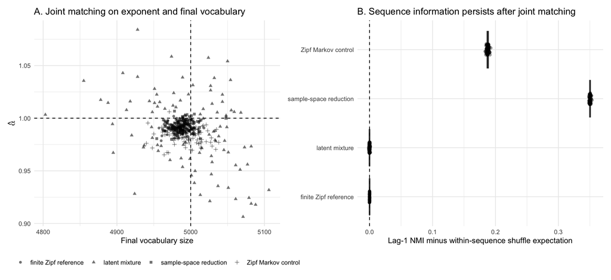

Figure 6: Jointly matching the marginal exponent and final vocabulary removes a trivial marginal discriminator while leaving order-sensitive structure visible.

```r
p_joint_robust <- plot_joint_sequence_robustness(rep_joint)
p_joint_robust
ggplot2::ggsave("figures/fig_joint_matching_sequence_v051.pdf", p_joint_robust, width = 12, height = 5.5)
```

# 8. Observation-window dependence and Zipf mimicry

The compatible/mimicking benchmark is not forced into the strict equivalence class. Instead it tests whether the fitted exponent itself changes materially with the analyst’s rank window.

```r
strict_sens <- utils::read.csv("results/alpha_sensitivity_strict_replications.csv", stringsAsFactors = FALSE)
mimic_sens <- utils::read.csv("results/alpha_sensitivity_mimicking_replications.csv", stringsAsFactors = FALSE)
alpha_sens_all <- rbind(strict_sens, mimic_sens)
alpha_window_summary <- summarise_alpha_sensitivity_replications(alpha_sens_all)
utils::write.csv(
  alpha_window_summary,
  "tables/table_alpha_window_summary_v051.csv",
  row.names = FALSE
)
```

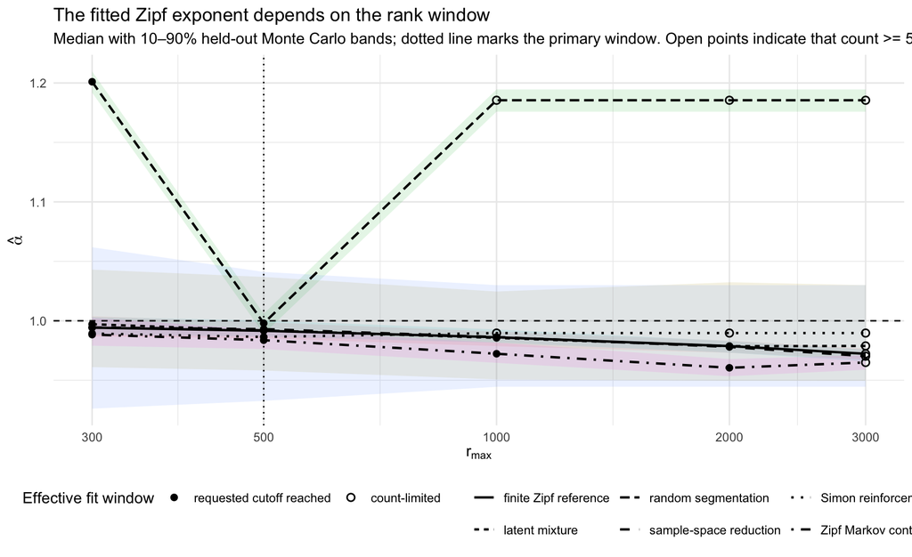

Figure 7: The fitted Zipf exponent can depend strongly on the requested rank window; open points denote windows truncated by the minimum-count rule.

```r
p_window <- plot_alpha_sensitivity(alpha_sens_all, primary_r_max = 500L)
p_window
ggplot2::ggsave("figures/fig_alpha_window_sensitivity_v051.pdf", p_window, width = 9, height = 5.5)
```

# 9. Latent conditioning

The latent mixture is not identified by temporal diagnostics because it is exchangeable within sequence. Its informative diagnostic is instead **conditioning**: the pooled marginal may scale while scale-conditioned rank distributions do not.

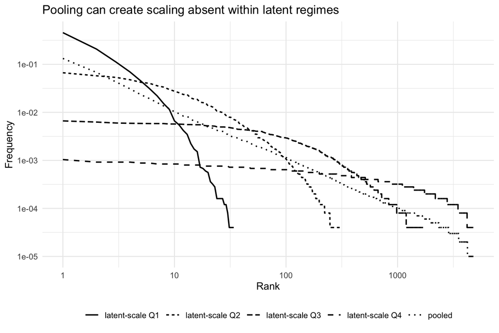

Figure 8: Pooling across latent scales can create marginal scaling absent within scale-conditioned regimes.

```r
p_latent <- plot_latent_conditioning(sims_strict$latent)
p_latent
ggplot2::ggsave("figures/fig_latent_conditioning_v051.pdf", p_latent, width = 7.5, height = 5)
```

# 10. Outputs for the paper

The main paper-facing outputs produced by this notebook are:

```
TABLES
  tables/table_calibration_exponent_v051.{csv,tex}
  tables/table_calibration_joint_v051.{csv,tex}
  tables/table_heldout_strict_v051.{csv,tex}
  tables/table_auc_bootstrap_key_v051.{csv,tex}
  tables/table_nmi_sensitivity_v051.{csv,tex}
  tables/table_joint_matching_v051.{csv,tex}

FIGURES
  figures/fig_rank_frequency_v051.pdf
  figures/fig_alpha_estimator_robustness_v051.pdf
  figures/fig_sequence_identification_v051.pdf
  figures/fig_bootstrap_key_diagnostics_v051.pdf
  figures/fig_nmi_topk_sensitivity_v051.pdf
  figures/fig_joint_matching_sequence_v051.pdf
  figures/fig_alpha_window_sensitivity_v051.pdf
  figures/fig_latent_conditioning_v051.pdf
```

The benchmark supports a deliberately limited inferential claim: a fitted Zipf exponent can leave very different constructions observationally difficult to distinguish under one marginal summary, while conditioning, vocabulary accumulation, and temporal diagnostics can progressively separate them. The Markov control is essential because it prevents generic serial dependence from being mistaken for an SSR-specific signature.

```r
writeLines(session_text, "results/sessionInfo.txt")
```

## References

Aitchison, Laurence, Nicola Corradi, and Peter E. Latham. 2016. “Zipf’s Law Arises Naturally When There Are Underlying, Unobserved Variables.” *PLoS Computational Biology* 12 (12): e1005110. https://doi.org/10.1371/journal.pcbi.1005110.

Clauset, Aaron, Cosma Rohilla Shalizi, and M. E. J. Newman. 2009. “Power-Law Distributions in Empirical Data.” *SIAM Review* 51 (4): 661–703. https://doi.org/10.1137/070710111.

Conrad, Brian, and Michael Mitzenmacher. 2004. “Power Laws for Monkeys Typing Randomly: The Case of Unequal Probabilities.” *IEEE Transactions on Information Theory* 50 (7): 1403–14.

Corominas-Murtra, Bernat, Rudolf Hanel, and Stefan Thurner. 2015. “Understanding Scaling Through History-Dependent Processes with Collapsing Sample Space.” *Proceedings of the National Academy of Sciences* 112 (17): 5348–53. https://doi.org/10.1073/pnas.1420946112.

Ferrer-i-Cancho, Ramon, and Brita Elvevåg. 2010. “Random Texts Do Not Exhibit the Real Zipf’s Law-Like Rank Distribution.” *PLoS ONE* 5 (3): e9411. https://doi.org/10.1371/journal.pone.0009411.

Li, Wentian. 1992. “Random Texts Exhibit Zipf’s-Law-Like Word Frequency Distribution.” *IEEE Transactions on Information Theory* 38 (6): 1842–45. https://doi.org/10.1109/18.165464.

Schwab, David J., Ilya Nemenman, and Pankaj Mehta. 2014. “Zipf’s Law and Criticality in Multivariate Data Without Fine-Tuning.” *Physical Review Letters* 113: 068102. https://doi.org/10.1103/PhysRevLett.113.068102.

Simon, Herbert A. 1955. “On a Class of Skew Distribution Functions.” *Biometrika* 42 (3–4): 425–40. https://doi.org/10.1093/biomet/42.3-4.425.

Thurner, Stefan, Rudolf Hanel, Bo Liu, and Bernat Corominas-Murtra. 2015. “Understanding Zipf’s Law of Word Frequencies Through Sample-Space Collapse in Sentence Formation.” *Journal of the Royal Society Interface* 12 (108): 20150330. https://doi.org/10.1098/rsif.2015.0330.